# Applied SFC modelling with R

Antoine Godin

12 May 2016

# Outline

# Installing the dependent libraries and the package

You need to install all the required libraries This is for traditional libraries

```r
install.packages("expm")
install.packages("igraph")
```

For non-conventional libraries, such as the one need to visualize DAGs, you need to do the following

```r
source("http://bioconductor.org/biocLite.R")
biocLite("Rgraphviz")
```

Finally you can then download the PKSFC package from github and install it locally

```r
install.packages("path/PKSFC_1.3.tar.gz", repos = NULL, type="source")
```

# Testing

Now we’re ready to load the package:

```r
library(PKSFC)
```

1. Load SIM (download SIM.txt from Github)

```r
sim<-sfc.model("SIM.txt",modelName="SIMplest model from chapter 3 of Godley and Lavoie (2007)")
```

2. Simulate the model

```r
datasim<-simulate(sim)
```

3. replicate figure 3.2 of page 73.

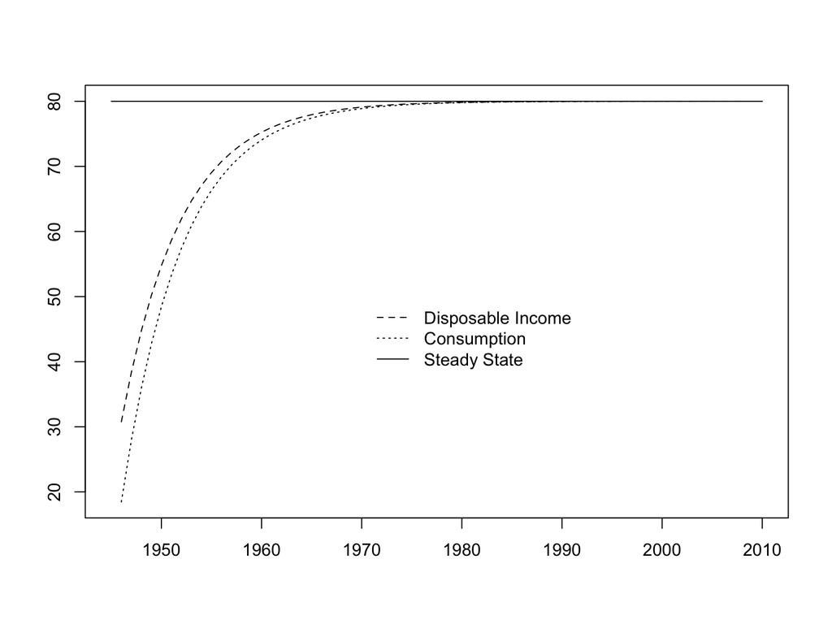

```r
plot(sim$time,datasim$baseline[,"Yd"],type="l", xlab="", ylab="", lty=2,
     ylim=range(datasim$baseline[,c("Yd","C_s")],na.rm=T))
lines(sim$time,datasim$baseline[,"C_s"],lty=3)
lines(sim$time,vector(length=length(sim$time))+datasim$baseline["2010","C_s"])
legend(x=1970,y=50,legend=c("Disposable Income","Consumption","Steady State"),lty=c(2,3,1),bty="n")
```

# How does it work?

- The package parses a text file containing the equations
- It generates an internal representation of the model
- Allows to simulate the model using a linear solver, the Gauss-Seidel Algorithm

# Source code of SIM

```r
#1. EQUATIONS
C_s = C_d
G_s = G_d
T_s = T_d
N_s = N_d
Yd = W*N_s - T_s
T_d = theta*W*N_s
C_d = alpha1*Yd + alpha2*H_h(-1)
H_s = H_s(-1) + G_d - T_d
H_h = H_h(-1) + Yd - C_d
Y = C_s + G_s
N_d = Y/W
#2. PARAMETERS
alpha1=0.6
alpha2=0.4
theta=0.2
#EXOGENOUS
G_d=20
W=1
#INITIAL VALUES
H_s=0
H_h=0
#3. Timeline
timeline 1945 2010
```

# A few important points regarding the model source code:

- The file should not contain any empty lines.
- You should avoid naming your variables with reserved names in R such as ‘in’ or ‘max’.
- There should be only one equation per line.
- There should be only one variable on the left hand side of the equation.
- You can use R functions such as min, max, or logical operators such as > or <=. In the case the logical operatur returns true, the numeric value will be one. Thus `(100>10)` will return `1`.
- The lag operator is represented by `(-x)` where `x` is the lag.
- There should not be any empty lines.
- You can add as many comments, using the `#` character at the begining of the line. Each comment exactly above an equation will be considered as the description of the equation and will be stored in the internal representation of the sfc model object.

# Internal representation

```r
print(sim)
```

```
## $name
## [1] "SIMplest model from chapter 3 of Godley and Lavoie (2007)"
##
## $simulated
## [1] FALSE
##
## $variables
##       name     initial value description
##  [1,] "C_s"    NA            "1. EQUATIONS"
##  [2,] "G_s"    NA            ""
##  [3,] "T_s"    NA            ""
##  [4,] "N_s"    NA            ""
##  [5,] "Yd"     NA            ""
##  [6,] "T_d"    NA            ""
##  [7,] "C_d"    NA            ""
##  [8,] "H_s"    "0"           ""
##  [9,] "H_h"    "0"           ""
## [10,] "Y"      NA            ""
## [11,] "N_d"    NA            ""
## [12,] "alpha1" "0.6"         "2. PARAMETERS"
## [13,] "alpha2" "0.4"         ""
## [14,] "theta"  "0.2"         ""
## [15,] "G_d"    "20"          "EXOGENOUS"
## [16,] "W"      "1"           ""
##
## $endogenous
##       name  initial value lag description
##  [1,] "C_s" NA            "0" "1. EQUATIONS"
##  [2,] "G_s" NA            "0" ""
##  [3,] "T_s" NA            "0" ""
##  [4,] "N_s" NA            "0" ""
##  [5,] "Yd"  NA            "0" ""
##  [6,] "T_d" NA            "0" ""
##  [7,] "C_d" NA            "0" ""
##  [8,] "H_s" "0"           "1" ""
##  [9,] "H_h" "0"           "1" ""
## [10,] "Y"   NA            "0" ""
## [11,] "N_d" NA            "0" ""
##
## $equations
```

[output cut: 29 more lines]

```
## H_s   0   0   0   0  0   1   0   0   0 0   0
## H_h   0   0   0   0  1   0   1   0   0 0   0
## Y     1   1   0   0  0   0   0   0   0 0   0
## N_d   0   0   0   0  0   0   0   0   0 1   0
##
## $blocks
## $blocks[[1]]
## [1] 2
##
## $blocks[[2]]
##  [1]  1  3  4  6  7  8 10 11  5  9
##
##
## attr(,"class")
## [1] "sfc"
```

# The Gauss Seidel Algorithm

# Direct Acyclic graphs

```r
simex<-sfc.model("SIMEX.txt",modelName="SIMplest model with expectation")
layout(matrix(c(1,2),1,2))
plot_graph_hierarchy(graph=generate.DAG.collaspe(adjacency=t(sim$matrix))$orginal_graph,
                     main="SIM" )
```

```
## [1] "We now have a DAG to work with!"
```

```
## [1] "We now have a DAG to work with!"
```

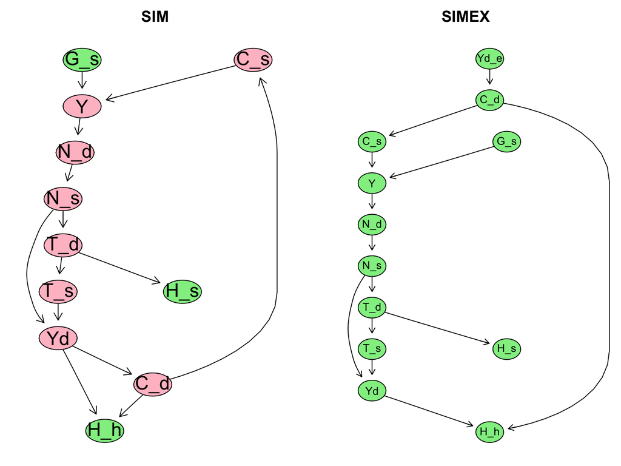

```r
plot_graph_hierarchy(graph=generate.DAG.collaspe(adjacency=t(simex$matrix))$orginal_graph,
                     main="SIMEX" )
```

# Systems of dependent vs independent equations

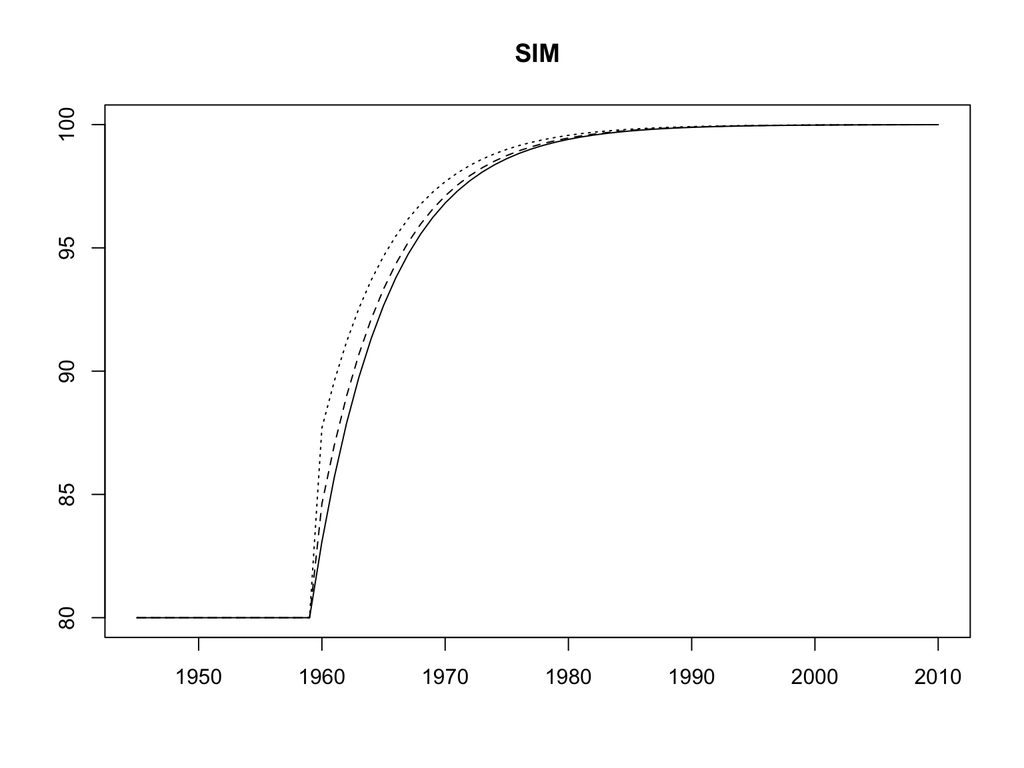

```r
datasimex<-simulate(simex)
init = datasimex$baseline[66,]
simex<-sfc.addScenario(simex,"G_d",25,1960,2010,init)
datasimex<-simulate(simex)
datasim<-simulate(sim)
init = datasim$baseline[66,]
sim<-sfc.addScenario(sim,"G_d",25,1960,2010,init)
datasim<-simulate(sim)
plot(sim$time,datasim$scenario_1[,"H_s"],type="l",xlab="",ylab="",main="SIM")
lines(sim$time,datasim$scenario_1[,"C_d"],lty=2)
lines(sim$time,datasim$scenario_1[,"Yd"],lty=3)
legend(x=1944,y=130,legend=c("Wealth","Consumption","Disposable Income"),
       lty=c(1,2,3),bty="n")
```

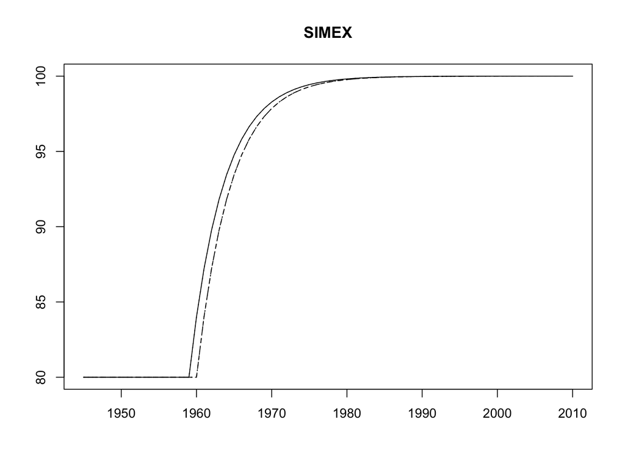

```r
plot(simex$time,datasimex$scenario_1[,"H_s"],type="l",xlab="",ylab="",main="SIMEX")
lines(simex$time,datasimex$scenario_1[,"C_d"],lty=2)
lines(simex$time,datasimex$scenario_1[,"Yd"],lty=3)
lines(simex$time,datasimex$scenario_1[,"Yd_e"],lty=4)
legend(x=1944,y=130,legend=c("Wealth","Consumption","Disposable Income",
                             "Expecetd Disposable Income"),lty=c(1,2,3,4),bty="n")
```

# Computational implications

Let’s see how much time it takes to run sim:

```r
ptm <- proc.time()
data1<-simulate(sim)
print(paste("Elapsed time is ",proc.time()[3]-ptm[3],"seconds"))
```

```
## [1] "Elapsed time is  8.246 seconds"
```

Now lets play with some of the parameters of the simulate function:

1. tolValue

```r
ptm <- proc.time()
data2<-simulate(sim,tolValue = 1e-3)
print(paste("Elapsed time is ",proc.time()[3]-ptm[3],"seconds"))
```

```
## [1] "Elapsed time is  0.376999999999999 seconds"
```

2. maxIter

```r
ptm <- proc.time()
data3<-simulate(sim, maxIter=10)
print(paste("Elapsed time is ",proc.time()[3]-ptm[3],"seconds"))
```

```
## [1] "Elapsed time is  0.347000000000001 seconds"
```

# Observing the results of the three simulations

```r
library(knitr)
kable(round(t(data1$baseline[c(1,2,20,40,66),c("G_d","Y","T_d","Yd","C_d","H_s","H_h")]),digits=3))
```

|  | 1945 | 1946 | 1964 | 1984 | 2010 |
| --- | --- | --- | --- | --- | --- |
| G_d | 20 | 20.000 | 20.000 | 20.000 | 20.000 |
| Y | NA | 38.462 | 96.957 | 99.892 | 99.999 |
| T_d | NA | 7.692 | 19.391 | 19.978 | 20.000 |
| Yd | NA | 30.769 | 77.566 | 79.914 | 79.999 |
| C_d | NA | 18.462 | 76.957 | 79.892 | 79.999 |
| H_s | 0 | 12.308 | 76.653 | 79.882 | 79.998 |
| H_h | 0 | 12.308 | 76.653 | 79.882 | 79.998 |

```r
kable(round(t(data2$baseline[c(1,2,20,40,66),c("G_d","Y","T_d","Yd","C_d","H_s","H_h")]),digits=3))
```

|  | 1945 | 1946 | 1964 | 1984 | 2010 |
| --- | --- | --- | --- | --- | --- |
| G_d | 20 | 20.000 | 20.000 | 20.000 | 20.000 |
| Y | NA | 38.453 | 96.894 | 99.348 | 99.812 |
| T_d | NA | 7.690 | 19.359 | 19.865 | 19.957 |
| Yd | NA | 30.760 | 77.430 | 79.470 | 79.829 |
| C_d | NA | 18.455 | 76.863 | 79.391 | 79.827 |
| H_s | 0 | 12.310 | 76.779 | 82.414 | 84.470 |
| H_h | 0 | 12.305 | 76.549 | 79.375 | 79.834 |

```r
kable(round(t(data3$baseline[c(1,2,20,40,66),c("G_d","Y","T_d","Yd","C_d","H_s","H_h")]),digits=3))
```

|  | 1945 | 1946 | 1964 | 1984 | 2010 |
| --- | --- | --- | --- | --- | --- |
| G_d | 20 | 20.000 | 20.000 | 20.000 | 20.000 |
| Y | NA | 29.480 | 94.662 | 99.687 | 99.992 |
| T_d | NA | 6.496 | 18.888 | 19.935 | 19.998 |
| Yd | NA | 28.480 | 75.551 | 79.739 | 79.993 |
| C_d | NA | 9.888 | 74.708 | 79.690 | 79.992 |
| H_s | 0 | 15.904 | 102.434 | 109.307 | 109.725 |
| H_h | 0 | 6.952 | 74.272 | 79.664 | 79.992 |

# Block Gauss-Seidel

The order of equations matters, if first compute variables that do not depend on current period, speeds the process. Define blocks of equation independent from the others.

```r
print(simex)
```

```
## $name
## [1] "SIMplest model with expectation"
##
## $simulated
## [1] FALSE
##
## $variables
##       name     initial value description
##  [1,] "C_s"    NA            "1. EQUATIONS"
##  [2,] "G_s"    NA            ""
##  [3,] "T_s"    NA            ""
##  [4,] "N_s"    NA            ""
##  [5,] "Yd"     "0"           ""
##  [6,] "T_d"    NA            ""
##  [7,] "C_d"    NA            ""
##  [8,] "H_s"    "0"           ""
##  [9,] "H_h"    "0"           ""
## [10,] "Y"      NA            ""
## [11,] "Yd_e"   NA            ""
## [12,] "N_d"    NA            ""
## [13,] "alpha1" "0.6"         "2. PARAMETERS"
## [14,] "alpha2" "0.4"         ""
## [15,] "theta"  "0.2"         ""
## [16,] "G_d"    "20"          "EXOGENOUS"
## [17,] "W"      "1"           ""
##
## $endogenous
##       name   initial value lag description
##  [1,] "C_s"  NA            "0" "1. EQUATIONS"
##  [2,] "G_s"  NA            "0" ""
##  [3,] "T_s"  NA            "0" ""
##  [4,] "N_s"  NA            "0" ""
##  [5,] "Yd"   "0"           "1" ""
##  [6,] "T_d"  NA            "0" ""
##  [7,] "C_d"  NA            "0" ""
##  [8,] "H_s"  "0"           "1" ""
##  [9,] "H_h"  "0"           "1" ""
## [10,] "Y"    NA            "0" ""
## [11,] "Yd_e" NA            "0" ""
## [12,] "N_d"  NA            "0" ""
```

[output cut: 87 more lines]

```
##           T_d           C_d           H_s           H_h             Y
##      19.99999      79.99995      79.99996      79.99996      99.99995
##          Yd_e           N_d        alpha1        alpha2         theta
##      79.99995      99.99995       0.60000       0.40000       0.20000
##           G_d             W  iter block 1  iter block 2  iter block 3
##      20.00000       1.00000       2.00000       2.00000       2.00000
##  iter block 4  iter block 5  iter block 6  iter block 7  iter block 8
##       2.00000       2.00000       2.00000       2.00000       2.00000
##  iter block 9 iter block 10
##       2.00000       2.00000
##
##
##
## attr(,"class")
## [1] "sfc"
```

# Simulation of SIMEX

```r
ptm <- proc.time()
dataex<-simulate(simex,tolValue = 1e-10)
print(paste("Elapsed time is ",proc.time()[3]-ptm[3],"seconds"))
```

```
## [1] "Elapsed time is  0.254000000000001 seconds"
```

# Results for SIMEX

```r
kable(round(t(dataex$baseline[c(1,2,20,40,66),c("G_d","Y","T_d","Yd","Yd_e","C_d","H_s","H_h")]),digits=3))
```

|  | 1945 | 1946 | 1964 | 1984 | 2010 |
| --- | --- | --- | --- | --- | --- |
| G_d | 20 | 20 | 20.000 | 20.000 | 20 |
| Y | NA | 20 | 98.559 | 99.983 | 100 |
| T_d | NA | 4 | 19.712 | 19.997 | 20 |
| Yd | 0 | 16 | 78.847 | 79.987 | 80 |
| Yd_e | NA | 0 | 78.559 | 79.983 | 80 |
| C_d | NA | 0 | 78.559 | 79.983 | 80 |
| H_s | 0 | 16 | 78.847 | 79.987 | 80 |
| H_h | 0 | 16 | 78.847 | 79.987 | 80 |

# Output data structure

- Output is a list of matrix where each element of the list are a scenario
- baseline
- scenario_i
- In the result matrix, there is a column indicating the number of iteration in the Gauss-Seidel algorithm per block of equations per period

```r
kable(dataex$baseline)
```

[output not shown]

# Checking the number of iteractions

- For sim, no simulate parameters:

```r
kable(round(t(data1$baseline[c(1,2,20,40,66),c("iter block 2")]),digits=3))
```

[output not shown]

```r
kable(round(t(data2$baseline[c(1,2,20,40,66),c("iter block 2")]),digits=3))
```

[output not shown]

```r
kable(round(t(data2$baseline[c(1,2,20,40,66),c("iter block 2")]),digits=3))
```

[output not shown]

```r
kable(round(t(dataex$baseline[c(1,2,20,40,66),c("iter block 1","iter block 2","iter block 3","iter block 4","iter block 5","iter block 6")]),digits=3))
```

|  | 1945 | 1946 | 1964 | 1984 | 2010 |
| --- | --- | --- | --- | --- | --- |
| iter block 1 | 0 | 2 | 2 | 2 | 2 |
| iter block 2 | 0 | 2 | 2 | 2 | 2 |
| iter block 3 | 0 | 2 | 2 | 2 | 2 |
| iter block 4 | 0 | 2 | 2 | 2 | 2 |
| iter block 5 | 0 | 2 | 2 | 2 | 2 |
| iter block 6 | 0 | 2 | 2 | 2 | 2 |